# INN_Learner_Notebook_Full_code_version

Bank Churn Prediction

## Problem Statement

### Context

Businesses like banks which provide service have to worry about problem of 'Customer Churn' i.e. customers leaving and joining another service provider. It is important to understand which aspects of the service influence a customer's decision in this regard. Management can concentrate efforts on improvement of service, keeping in mind these priorities.

### Objective

You as a Data scientist with the bank need to build a neural network based classifier that can determine whether a customer will leave the bank or not in the next 6 months.

### Data Dictionary

- CustomerId: Unique ID which is assigned to each customer
- Surname: Last name of the customer
- CreditScore: It defines the credit history of the customer.
- Geography: A customer’s location
- Gender: It defines the Gender of the customer
- Age: Age of the customer
- Tenure: Number of years for which the customer has been with the bank
- NumOfProducts: refers to the number of products that a customer has purchased through the bank.
- Balance: Account balance
- HasCrCard: It is a categorical variable which decides whether the customer has credit card or not.
- EstimatedSalary: Estimated salary
- isActiveMember: Is is a categorical variable which decides whether the customer is active member of the bank or not ( Active member in the sense, using bank products regularly, making transactions etc )
- Exited : whether or not the customer left the bank within six month. It can take two values ** 0=No ( Customer did not leave the bank ) ** 1=Yes ( Customer left the bank )

```python
!pip install tensorflow
```

## Importing necessary libraries

```python
# Libraries to help with reading and manipulating data
import pandas as pd
import numpy as np

# libaries to help with data visualization
import matplotlib.pyplot as plt
import seaborn as sns

# Library to split data
from sklearn.model_selection import train_test_split

# library to import to standardize the data
from sklearn.preprocessing import StandardScaler, LabelEncoder

# importing different functions to build models
import tensorflow as tf
from tensorflow import keras
from keras import backend
from keras.models import Sequential
from keras.layers import Dense, Dropout

# importing SMOTE
from imblearn.over_sampling import SMOTE

# importing metrics
from sklearn.metrics import confusion_matrix,roc_curve,classification_report,recall_score

import random

# Library to avoid the warnings
import warnings
warnings.filterwarnings("ignore")
```

## Loading the dataset

```python
ds = pd.read_csv("Churn.csv")
```

## Data Overview

```python
ds.head()
```

|  | RowNumber | CustomerId | Surname | CreditScore | Geography | Gender | Age | Tenure | Balance | NumOfProducts | HasCrCard | IsActiveMember | EstimatedSalary | Exited |
| --- | --- | --- | --- | --- | --- | --- | --- | --- | --- | --- | --- | --- | --- | --- |
| 0 | 1 | 15634602 | Hargrave | 619 | France | Female | 42 | 2 | 0.00 | 1 | 1 | 1 | 101348.88 | 1 |
| 1 | 2 | 15647311 | Hill | 608 | Spain | Female | 41 | 1 | 83807.86 | 1 | 0 | 1 | 112542.58 | 0 |
| 2 | 3 | 15619304 | Onio | 502 | France | Female | 42 | 8 | 159660.80 | 3 | 1 | 0 | 113931.57 | 1 |
| 3 | 4 | 15701354 | Boni | 699 | France | Female | 39 | 1 | 0.00 | 2 | 0 | 0 | 93826.63 | 0 |
| 4 | 5 | 15737888 | Mitchell | 850 | Spain | Female | 43 | 2 | 125510.82 | 1 | 1 | 1 | 79084.10 | 0 |

```python
ds.tail()
```

|  | RowNumber | CustomerId | Surname | CreditScore | Geography | Gender | Age | Tenure | Balance | NumOfProducts | HasCrCard | IsActiveMember | EstimatedSalary | Exited |
| --- | --- | --- | --- | --- | --- | --- | --- | --- | --- | --- | --- | --- | --- | --- |
| 9995 | 9996 | 15606229 | Obijiaku | 771 | France | Male | 39 | 5 | 0.00 | 2 | 1 | 0 | 96270.64 | 0 |
| 9996 | 9997 | 15569892 | Johnstone | 516 | France | Male | 35 | 10 | 57369.61 | 1 | 1 | 1 | 101699.77 | 0 |
| 9997 | 9998 | 15584532 | Liu | 709 | France | Female | 36 | 7 | 0.00 | 1 | 0 | 1 | 42085.58 | 1 |
| 9998 | 9999 | 15682355 | Sabbatini | 772 | Germany | Male | 42 | 3 | 75075.31 | 2 | 1 | 0 | 92888.52 | 1 |
| 9999 | 10000 | 15628319 | Walker | 792 | France | Female | 28 | 4 | 130142.79 | 1 | 1 | 0 | 38190.78 | 0 |

```python
ds.shape
```

```
(10000, 14)
```

```python
ds.info()
```

```
<class 'pandas.core.frame.DataFrame'>
RangeIndex: 10000 entries, 0 to 9999
Data columns (total 14 columns):
 #   Column           Non-Null Count  Dtype
---  ------           --------------  -----
 0   RowNumber        10000 non-null  int64
 1   CustomerId       10000 non-null  int64
 2   Surname          10000 non-null  object
 3   CreditScore      10000 non-null  int64
 4   Geography        10000 non-null  object
 5   Gender           10000 non-null  object
 6   Age              10000 non-null  int64
 7   Tenure           10000 non-null  int64
 8   Balance          10000 non-null  float64
 9   NumOfProducts    10000 non-null  int64
 10  HasCrCard        10000 non-null  int64
 11  IsActiveMember   10000 non-null  int64
 12  EstimatedSalary  10000 non-null  float64
 13  Exited           10000 non-null  int64
dtypes: float64(2), int64(9), object(3)
memory usage: 1.1+ MB
```

- As observed, there are no missing values in the dataset.

```python
ds.describe().T
```

|  | count | mean | std | min | 25% | 50% | 75% | max |
| --- | --- | --- | --- | --- | --- | --- | --- | --- |
| RowNumber | 10000.0 | 5.000500e+03 | 2886.895680 | 1.00 | 2500.75 | 5.000500e+03 | 7.500250e+03 | 10000.00 |
| CustomerId | 10000.0 | 1.569094e+07 | 71936.186123 | 15565701.00 | 15628528.25 | 1.569074e+07 | 1.575323e+07 | 15815690.00 |
| CreditScore | 10000.0 | 6.505288e+02 | 96.653299 | 350.00 | 584.00 | 6.520000e+02 | 7.180000e+02 | 850.00 |
| Age | 10000.0 | 3.892180e+01 | 10.487806 | 18.00 | 32.00 | 3.700000e+01 | 4.400000e+01 | 92.00 |
| Tenure | 10000.0 | 5.012800e+00 | 2.892174 | 0.00 | 3.00 | 5.000000e+00 | 7.000000e+00 | 10.00 |
| Balance | 10000.0 | 7.648589e+04 | 62397.405202 | 0.00 | 0.00 | 9.719854e+04 | 1.276442e+05 | 250898.09 |
| NumOfProducts | 10000.0 | 1.530200e+00 | 0.581654 | 1.00 | 1.00 | 1.000000e+00 | 2.000000e+00 | 4.00 |
| HasCrCard | 10000.0 | 7.055000e-01 | 0.455840 | 0.00 | 0.00 | 1.000000e+00 | 1.000000e+00 | 1.00 |
| IsActiveMember | 10000.0 | 5.151000e-01 | 0.499797 | 0.00 | 0.00 | 1.000000e+00 | 1.000000e+00 | 1.00 |
| EstimatedSalary | 10000.0 | 1.000902e+05 | 57510.492818 | 11.58 | 51002.11 | 1.001939e+05 | 1.493882e+05 | 199992.48 |
| Exited | 10000.0 | 2.037000e-01 | 0.402769 | 0.00 | 0.00 | 0.000000e+00 | 0.000000e+00 | 1.00 |

```python
# Checking for null values in the dataset
ds.isnull().sum()
```

```
RowNumber          0
CustomerId         0
Surname            0
CreditScore        0
Geography          0
Gender             0
Age                0
Tenure             0
Balance            0
NumOfProducts      0
HasCrCard          0
IsActiveMember     0
EstimatedSalary    0
Exited             0
dtype: int64
```

- There are no null values in the dataset.

```python
# Checking for unique values in the dataset
ds.nunique()
```

```
RowNumber          10000
CustomerId         10000
Surname             2932
CreditScore          460
Geography              3
Gender                 2
Age                   70
Tenure                11
Balance             6382
NumOfProducts          4
HasCrCard              2
IsActiveMember         2
EstimatedSalary     9999
Exited                 2
dtype: int64
```

```python
ds = ds.drop(['RowNumber', 'CustomerId', 'Surname'], axis=1)
```

## Exploratory Data Analysis

### Univariate Analysis

```python
# function to plot a boxplot and a histogram along the same scale.


def histogram_boxplot(data, feature, figsize=(12, 7), kde=False, bins=None):
    """
    Boxplot and histogram combined

    data: dataframe
    feature: dataframe column
    figsize: size of figure (default (12,7))
    kde: whether to show the density curve (default False)
    bins: number of bins for histogram (default None)
    """
    f2, (ax_box2, ax_hist2) = plt.subplots(
        nrows=2,  # Number of rows of the subplot grid= 2
        sharex=True,  # x-axis will be shared among all subplots
        gridspec_kw={"height_ratios": (0.25, 0.75)},
        figsize=figsize,
    )  # creating the 2 subplots
    sns.boxplot(
        data=data, x=feature, ax=ax_box2, showmeans=True, color="violet"
    )  # boxplot will be created and a star will indicate the mean value of the column
    sns.histplot(
        data=data, x=feature, kde=kde, ax=ax_hist2, bins=bins, palette="winter"
    ) if bins else sns.histplot(
        data=data, x=feature, kde=kde, ax=ax_hist2
    )  # For histogram
    ax_hist2.axvline(
        data[feature].mean(), color="green", linestyle="--"
    )  # Add mean to the histogram
    ax_hist2.axvline(
        data[feature].median(), color="black", linestyle="-"
    )  # Add median to the histogram
```

```python
# function to create labeled barplots


def labeled_barplot(data, feature, perc=False, n=None):
    """
    Barplot with percentage at the top

    data: dataframe
    feature: dataframe column
    perc: whether to display percentages instead of count (default is False)
    n: displays the top n category levels (default is None, i.e., display all levels)
    """

    total = len(data[feature])  # length of the column
    count = data[feature].nunique()
    if n is None:
        plt.figure(figsize=(count + 1, 5))
    else:
        plt.figure(figsize=(n + 1, 5))

    plt.xticks(rotation=90, fontsize=15)
    ax = sns.countplot(
        data=data,
        x=feature,
        palette="Paired",
        order=data[feature].value_counts().index[:n].sort_values(),
    )

    for p in ax.patches:
        if perc == True:
            label = "{:.1f}%".format(
                100 * p.get_height() / total
            )  # percentage of each class of the category
        else:
            label = p.get_height()  # count of each level of the category

        x = p.get_x() + p.get_width() / 2  # width of the plot
        y = p.get_height()  # height of the plot

        ax.annotate(
            label,
            (x, y),
            ha="center",
            va="center",
            size=12,
            xytext=(0, 5),
            textcoords="offset points",
        )  # annotate the percentage

    plt.show()  # show the plot
```

#### Observations on CreditScore

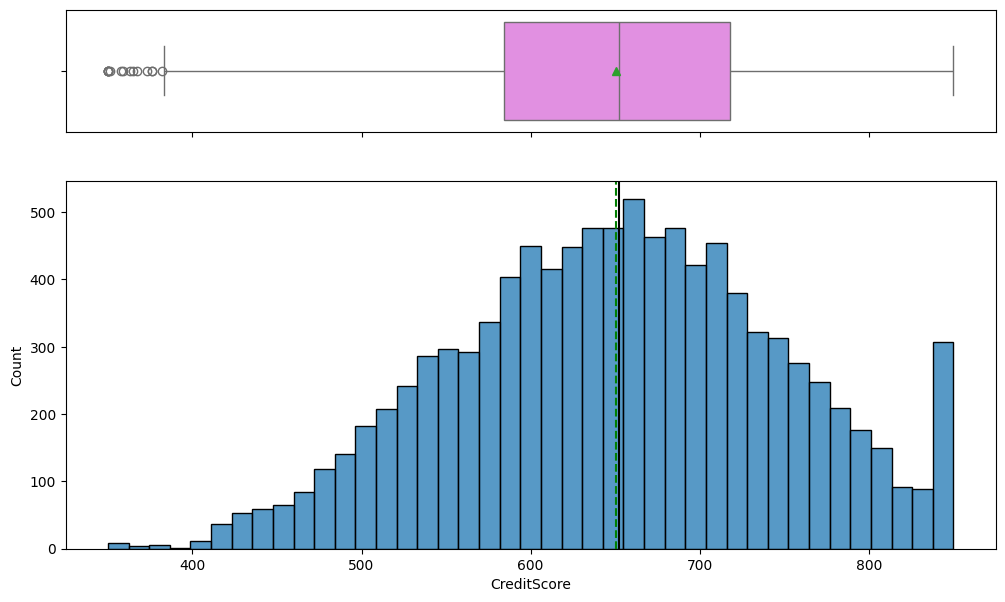

```python
histogram_boxplot(ds,'CreditScore')
```

- Distribution is almost normal
- There are some outliers but still in the expected credit score range

#### Observations on Age

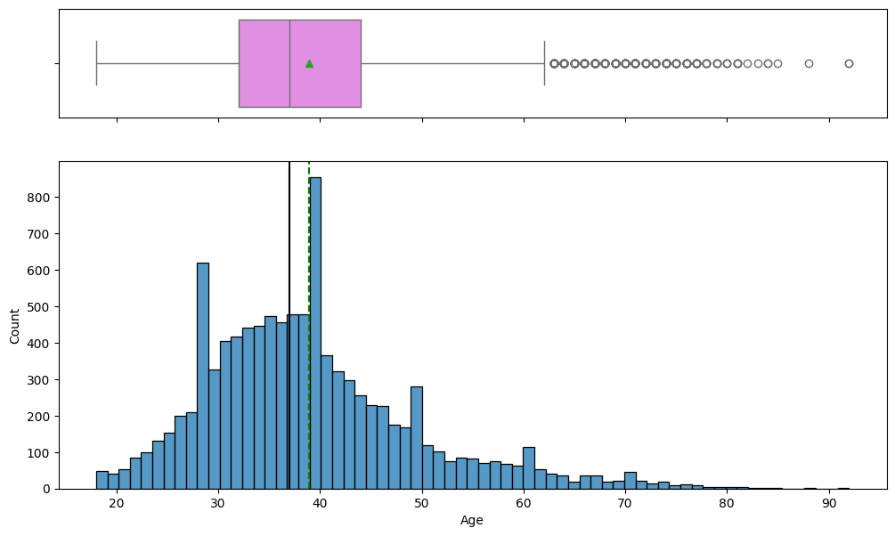

```python
histogram_boxplot(ds,'Age')
```

- Distribution is right skewed
- There are some outliers and they are in older age range.

#### Observations on Balance

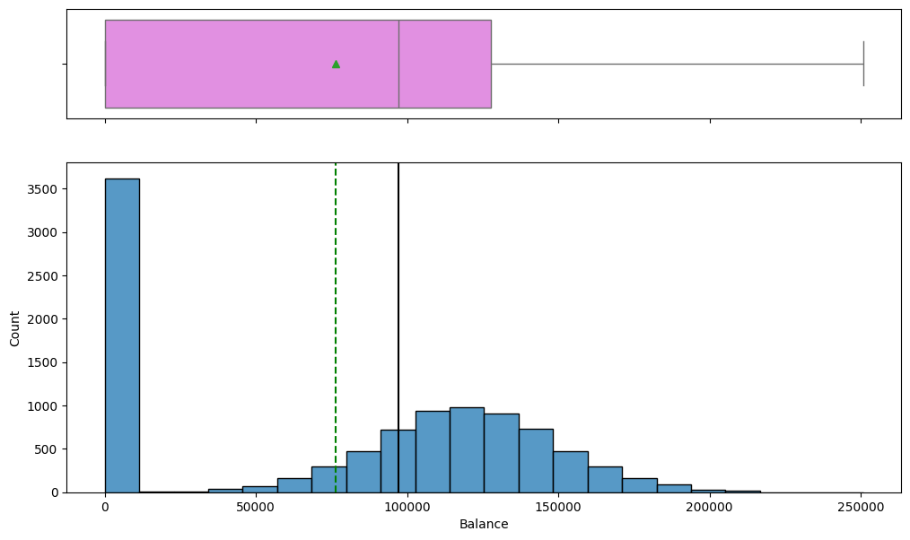

```python
histogram_boxplot(ds,'Balance')
```

- Distribution is left skewed due to having a great number of customers with 0 balance. Otherwise the distribution would have been normal.
- There are no outliers.

#### Observations on Estimated Salary

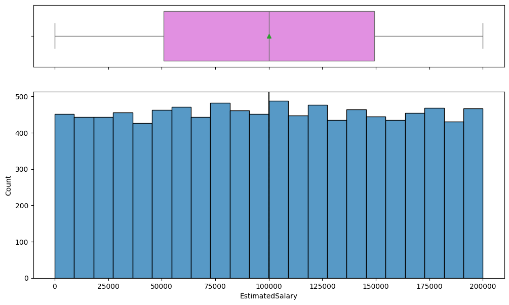

```python
histogram_boxplot(ds,'EstimatedSalary')
```

#### Observations on Exited

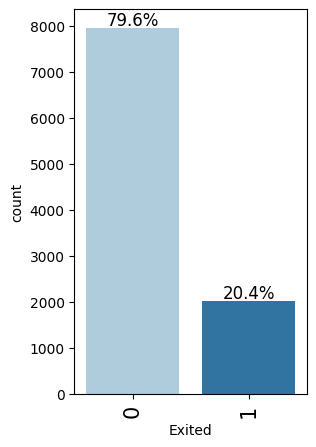

```python
labeled_barplot(ds, "Exited", perc=True)
```

- Close to 80% are not Churned and 20% are Churned.
- This is an imbalanced dataset.

### Bivariate Analysis

```python
# function to plot stacked bar chart


def stacked_barplot(data, predictor, target):
    """
    Print the category counts and plot a stacked bar chart

    data: dataframe
    predictor: independent variable
    target: target variable
    """
    count = data[predictor].nunique()
    sorter = data[target].value_counts().index[-1]
    tab1 = pd.crosstab(data[predictor], data[target], margins=True).sort_values(
        by=sorter, ascending=False
    )
    print(tab1)
    print("-" * 120)
    tab = pd.crosstab(data[predictor], data[target], normalize="index").sort_values(
        by=sorter, ascending=False
    )
    tab.plot(kind="bar", stacked=True, figsize=(count + 1, 5))
    plt.legend(
        loc="lower left",
        frameon=False,
    )
    plt.legend(loc="upper left", bbox_to_anchor=(1, 1))
    plt.show()
```

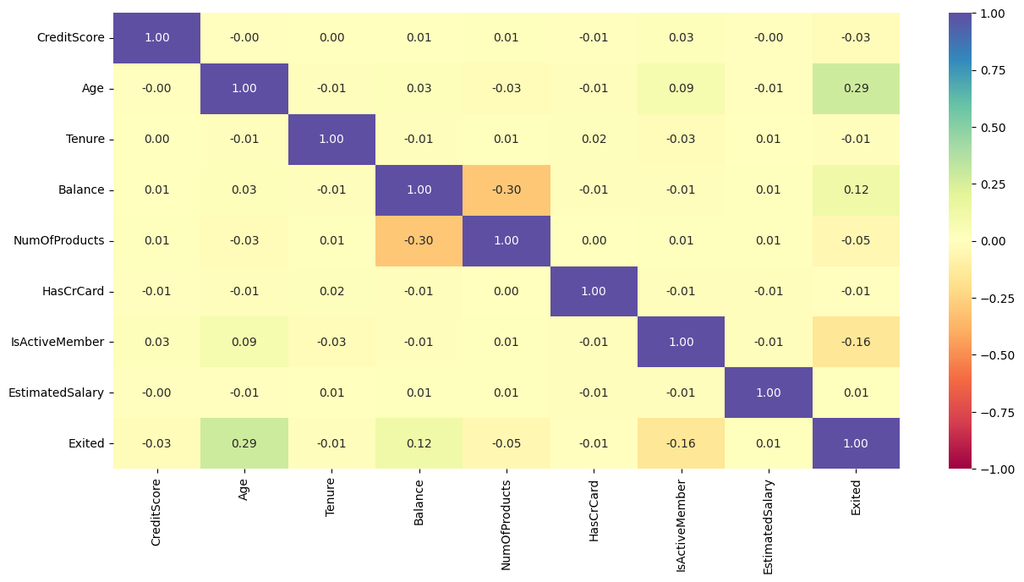

```python
plt.figure(figsize=(15, 7))
sns.heatmap(ds.select_dtypes(include=[np.number]).corr('pearson'), annot=True, vmin=-1, vmax=1, fmt=".2f", cmap="Spectral")
plt.show()
```

- None of the data points are highly correlated with each other.

#### Exited Vs Geography

```
Exited        0     1    All
Geography
All        7963  2037  10000
Germany    1695   814   2509
France     4204   810   5014
Spain      2064   413   2477
------------------------------------------------------------------------------------------------------------------------
```

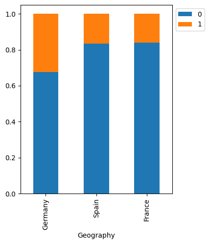

```python
stacked_barplot(ds, "Geography", "Exited" )
```

- Majority of the customers are churned from the Germany compared to Spain and France.

#### Exited Vs Gender

```
Exited     0     1    All
Gender
All     7963  2037  10000
Female  3404  1139   4543
Male    4559   898   5457
------------------------------------------------------------------------------------------------------------------------
```

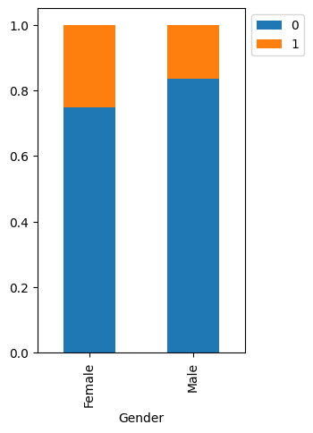

```python
stacked_barplot(ds, "Gender", "Exited" )
```

- Majority of the customers are churned from the Female compared to Male.

#### Exited Vs CreditCard

```
Exited        0     1    All
HasCrCard
All        7963  2037  10000
1          5631  1424   7055
0          2332   613   2945
------------------------------------------------------------------------------------------------------------------------
```

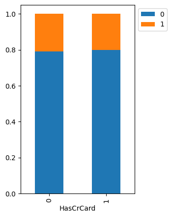

```python
stacked_barplot(ds, "HasCrCard", "Exited" )
```

- There is no difference between the churned and not churned customers based on the credit card.

#### Exited Vs IsActiveMember

```
Exited             0     1    All
IsActiveMember
All             7963  2037  10000
0               3547  1302   4849
1               4416   735   5151
------------------------------------------------------------------------------------------------------------------------
```

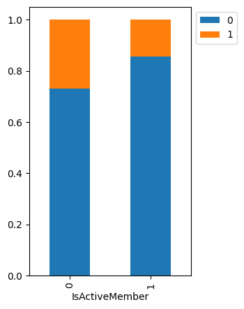

```python
stacked_barplot(ds, "IsActiveMember", "Exited" )
```

- inactive members have a greater churn.

#### CreditScore Vs Exited

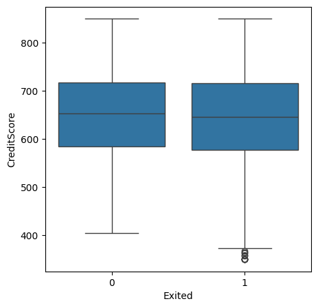

```python
plt.figure(figsize=(5,5))
sns.boxplot(y='CreditScore',x='Exited',data=ds)
plt.show()
```

- Both Exited and Not Exited customers have almost similar credit scores.

## Data Preprocessing

### Train-validation-test Split

```python
# Splitting the data into train and test data, removing the Exited column from the train data.
X = ds.drop('Exited', axis=1)
y = ds['Exited']
```

```python
# Splitting the dataset into the Training and Testing set.

X_large, X_test, y_large, y_test = train_test_split(X,y, test_size = 0.2, random_state = 42,stratify=y)
```

```python
# Splitting the dataset into the Training and Validation set from Training Data set.

X_train, X_val, y_train, y_val = train_test_split(X_large,y_large, test_size = 0.25, random_state = 42,stratify=y_large)
```

```python
print(X_train.shape, X_val.shape, X_test.shape)
```

```
(6000, 10) (2000, 10) (2000, 10)
```

```python
print(y_train.shape, y_val.shape, y_test.shape)
```

```
(6000,) (2000,) (2000,)
```

### Dummy Variable Creation

```python
# Encoding Geography variable for Training, Test and Validation Datasets.
X_train = pd.get_dummies(X_train, columns=["Geography","Gender"],drop_first=True)
X_test = pd.get_dummies(X_test, columns=["Geography","Gender"],drop_first=True)
X_val = pd.get_dummies(X_val, columns=["Geography","Gender"],drop_first=True)
```

### Data Normalization

Since the data is not normally distributed, The columns CreditScore, Age, Tenure, Balance, and EstimatedSalary will be normalized.

```python
# defining the list of columns to normalize
cols_list = ["CreditScore","Age","Tenure","Balance","EstimatedSalary"]

# creating an instance of the standard scaler
sc = StandardScaler()

X_train[cols_list] = sc.fit_transform(X_train[cols_list])
X_val[cols_list] = sc.transform(X_val[cols_list])
X_test[cols_list] = sc.transform(X_test[cols_list])
```

## Model Building

### Model Evaluation Criterion

**Model can make wrong predictions as:**

- Predicting a customer is exiting and the customer is not exiting
- Predicting a customer is not exiting and customer is exiting

**Which case is more important?**

- Predicting that customer is not exiting but he/she is exiting. It might cause loss to the banks because due to wrong identification bank will not be able to take any initiative for those sensitive customers.

**How to reduce this loss i.e need to reduce False Negative?**

- Bank would want `Recall` to be maximized, greater the Recall higher the chances of minimizing false Negative. Hence, the focus should be on increasing Recall or minimizing the false Negative or in other words identifying the True Positive(i.e. Class 1) so that the bank can retain their customers.

```python
#Creating the Confusion Matrix Function for printing the stats of the model.
def make_confusion_matrix(actual_targets, predicted_targets):
    """
    To plot the confusion_matrix with percentages

    actual_targets: actual target (dependent) variable values
    predicted_targets: predicted target (dependent) variable values
    """
    cm = confusion_matrix(actual_targets, predicted_targets)
    labels = np.asarray(
        [
            ["{0:0.0f}".format(item) + "\n{0:.2%}".format(item / cm.flatten().sum())]
            for item in cm.flatten()
        ]
    ).reshape(cm.shape[0], cm.shape[1])

    plt.figure(figsize=(6, 4))
    sns.heatmap(cm, annot=labels, fmt="")
    plt.ylabel("True label")
    plt.xlabel("Predicted label")
```

```python
# Creating the empty dataframe for storing the results of the models
train_metric_df = pd.DataFrame(columns=["recall"])
valid_metric_df = pd.DataFrame(columns=["recall"])
```

### Neural Network with SGD Optimizer

```python
backend.clear_session()
#Fixing the seed for random number generators so that we can ensure we receive the same output everytime
np.random.seed(2)
random.seed(2)
tf.random.set_seed(2)
```

```python
#Initializing the neural network
model_0 = Sequential()
#Adding the input layer with 64 neurons and relu as activation function
model_0.add(Dense(64,activation='relu',input_dim = X_train.shape[1]))
# Adding the first hidden layer with 32 neurons with relu as activation functions
model_0.add(Dense(32,activation='relu'))
# Adding the output layer
model_0.add(Dense(1, activation = 'sigmoid'))
#Compiling the ANN with SGD optimizer.
optimizer = tf.keras.optimizers.SGD(0.001)
# Complining the model with binary cross entropy as loss function and accuracy as metrics
model_0.compile(loss='binary_crossentropy',optimizer=optimizer,metrics=[keras.metrics.Recall()])
```

```python
model_0.summary()
```

```
Model: "sequential"
```

```
┏━━━━━━━━━━━━━━━━━━━━━━━━━━━━━━━━━┳━━━━━━━━━━━━━━━━━━━━━━━━┳━━━━━━━━━━━━━━━┓
┃ Layer (type)                    ┃ Output Shape           ┃       Param # ┃
┡━━━━━━━━━━━━━━━━━━━━━━━━━━━━━━━━━╇━━━━━━━━━━━━━━━━━━━━━━━━╇━━━━━━━━━━━━━━━┩
│ dense (Dense)                   │ (None, 64)             │           768 │
├─────────────────────────────────┼────────────────────────┼───────────────┤
│ dense_1 (Dense)                 │ (None, 32)             │         2,080 │
├─────────────────────────────────┼────────────────────────┼───────────────┤
│ dense_2 (Dense)                 │ (None, 1)              │            33 │
└─────────────────────────────────┴────────────────────────┴───────────────┘
```

```
 Total params: 2,881 (11.25 KB)
```

```
 Trainable params: 2,881 (11.25 KB)
```

```
 Non-trainable params: 0 (0.00 B)
```

```python
X_train = np.asarray(X_train).astype(np.float32)
y_train = np.asarray(y_train).astype(np.float32)
X_val = np.asarray(X_val).astype(np.float32)
y_val = np.asarray(y_val).astype(np.float32)
```

```python
X_train
```

```
array([[-0.6943739 ,  0.48088953, -0.00957228, ...,  0.        ,
         0.        ,  0.        ],
       [-2.0499566 , -0.09156014,  1.0221707 , ...,  1.        ,
         0.        ,  0.        ],
       [ 1.5718291 ,  0.38548124, -0.6974009 , ...,  0.        ,
         1.        ,  1.        ],
       ...,
       [-0.43567494,  0.8625226 , -1.3852296 , ...,  0.        ,
         0.        ,  1.        ],
       [ 0.80608016, -1.2364595 , -0.3534866 , ...,  1.        ,
         0.        ,  1.        ],
       [ 0.9716475 ,  1.4349723 ,  1.0221707 , ...,  0.        ,
         1.        ,  0.        ]], dtype=float32)
```

```python
#Fitting the ANN with batch_size = 32 and 100 epochs
history_0 = model_0.fit(
    X_train,y_train,
    batch_size=32,
    validation_data=(X_val,y_val),
    epochs=100,
    verbose=1
)
```

```
188/188 ━━━━━━━━━━━━━━━━━━━━ 1s 2ms/step - loss: 0.6309 - recall: 0.1294 - val_loss: 0.5833 - val_recall: 0.0000e+00
188/188 ━━━━━━━━━━━━━━━━━━━━ 0s 1ms/step - loss: 0.5675 - recall: 0.0033 - val_loss: 0.5465 - val_recall: 0.0000e+00
188/188 ━━━━━━━━━━━━━━━━━━━━ 0s 1ms/step - loss: 0.5328 - recall: 0.0000e+00 - val_loss: 0.5257 - val_recall: 0.0000e+00
188/188 ━━━━━━━━━━━━━━━━━━━━ 0s 1ms/step - loss: 0.5127 - recall: 0.0000e+00 - val_loss: 0.5132 - val_recall: 0.0000e+00
188/188 ━━━━━━━━━━━━━━━━━━━━ 0s 1ms/step - loss: 0.5002 - recall: 0.0000e+00 - val_loss: 0.5051 - val_recall: 0.0000e+00
188/188 ━━━━━━━━━━━━━━━━━━━━ 0s 2ms/step - loss: 0.4918 - recall: 0.0000e+00 - val_loss: 0.4992 - val_recall: 0.0000e+00
188/188 ━━━━━━━━━━━━━━━━━━━━ 0s 1ms/step - loss: 0.4857 - recall: 0.0000e+00 - val_loss: 0.4947 - val_recall: 0.0000e+00
188/188 ━━━━━━━━━━━━━━━━━━━━ 0s 1ms/step - loss: 0.4809 - recall: 0.0000e+00 - val_loss: 0.4909 - val_recall: 0.0000e+00
188/188 ━━━━━━━━━━━━━━━━━━━━ 0s 1ms/step - loss: 0.4768 - recall: 0.0000e+00 - val_loss: 0.4876 - val_recall: 0.0000e+00
188/188 ━━━━━━━━━━━━━━━━━━━━ 0s 1ms/step - loss: 0.4733 - recall: 0.0000e+00 - val_loss: 0.4846 - val_recall: 0.0000e+00
188/188 ━━━━━━━━━━━━━━━━━━━━ 0s 2ms/step - loss: 0.4700 - recall: 0.0000e+00 - val_loss: 0.4818 - val_recall: 0.0000e+00
188/188 ━━━━━━━━━━━━━━━━━━━━ 0s 2ms/step - loss: 0.4671 - recall: 0.0000e+00 - val_loss: 0.4792 - val_recall: 0.0000e+00
188/188 ━━━━━━━━━━━━━━━━━━━━ 0s 2ms/step - loss: 0.4643 - recall: 0.0000e+00 - val_loss: 0.4768 - val_recall: 0.0000e+00
188/188 ━━━━━━━━━━━━━━━━━━━━ 0s 2ms/step - loss: 0.4617 - recall: 0.0000e+00 - val_loss: 0.4745 - val_recall: 0.0000e+00
188/188 ━━━━━━━━━━━━━━━━━━━━ 0s 2ms/step - loss: 0.4593 - recall: 0.0000e+00 - val_loss: 0.4723 - val_recall: 0.0000e+00
188/188 ━━━━━━━━━━━━━━━━━━━━ 0s 2ms/step - loss: 0.4570 - recall: 0.0012 - val_loss: 0.4702 - val_recall: 0.0000e+00
188/188 ━━━━━━━━━━━━━━━━━━━━ 0s 2ms/step - loss: 0.4548 - recall: 0.0013 - val_loss: 0.4683 - val_recall: 0.0000e+00
188/188 ━━━━━━━━━━━━━━━━━━━━ 0s 2ms/step - loss: 0.4527 - recall: 0.0013 - val_loss: 0.4665 - val_recall: 0.0000e+00
188/188 ━━━━━━━━━━━━━━━━━━━━ 0s 2ms/step - loss: 0.4507 - recall: 0.0013 - val_loss: 0.4647 - val_recall: 0.0025
188/188 ━━━━━━━━━━━━━━━━━━━━ 0s 1ms/step - loss: 0.4488 - recall: 0.0013 - val_loss: 0.4630 - val_recall: 0.0025
188/188 ━━━━━━━━━━━━━━━━━━━━ 0s 2ms/step - loss: 0.4470 - recall: 0.0015 - val_loss: 0.4614 - val_recall: 0.0025
188/188 ━━━━━━━━━━━━━━━━━━━━ 0s 2ms/step - loss: 0.4453 - recall: 0.0028 - val_loss: 0.4599 - val_recall: 0.0025
188/188 ━━━━━━━━━━━━━━━━━━━━ 0s 2ms/step - loss: 0.4436 - recall: 0.0049 - val_loss: 0.4585 - val_recall: 0.0074
188/188 ━━━━━━━━━━━━━━━━━━━━ 0s 2ms/step - loss: 0.4420 - recall: 0.0051 - val_loss: 0.4571 - val_recall: 0.0074
188/188 ━━━━━━━━━━━━━━━━━━━━ 0s 2ms/step - loss: 0.4405 - recall: 0.0074 - val_loss: 0.4558 - val_recall: 0.0098
188/188 ━━━━━━━━━━━━━━━━━━━━ 0s 2ms/step - loss: 0.4391 - recall: 0.0115 - val_loss: 0.4545 - val_recall: 0.0123
188/188 ━━━━━━━━━━━━━━━━━━━━ 0s 2ms/step - loss: 0.4377 - recall: 0.0115 - val_loss: 0.4533 - val_recall: 0.0172
188/188 ━━━━━━━━━━━━━━━━━━━━ 0s 2ms/step - loss: 0.4364 - recall: 0.0160 - val_loss: 0.4522 - val_recall: 0.0197
188/188 ━━━━━━━━━━━━━━━━━━━━ 0s 2ms/step - loss: 0.4351 - recall: 0.0197 - val_loss: 0.4511 - val_recall: 0.0270
188/188 ━━━━━━━━━━━━━━━━━━━━ 0s 2ms/step - loss: 0.4339 - recall: 0.0201 - val_loss: 0.4500 - val_recall: 0.0319
 44/188 ━━━━━━━━━━━━━━━━━━━━ 0s 1ms/step - loss: 0.4046 - recall: 0.0050
```

```
188/188 ━━━━━━━━━━━━━━━━━━━━ 0s 2ms/step - loss: 0.4327 - recall: 0.0222 - val_loss: 0.4490 - val_recall: 0.0393
188/188 ━━━━━━━━━━━━━━━━━━━━ 1s 3ms/step - loss: 0.4316 - recall: 0.0251 - val_loss: 0.4481 - val_recall: 0.0418
188/188 ━━━━━━━━━━━━━━━━━━━━ 0s 2ms/step - loss: 0.4305 - recall: 0.0278 - val_loss: 0.4472 - val_recall: 0.0467
188/188 ━━━━━━━━━━━━━━━━━━━━ 0s 2ms/step - loss: 0.4294 - recall: 0.0282 - val_loss: 0.4463 - val_recall: 0.0491
188/188 ━━━━━━━━━━━━━━━━━━━━ 0s 2ms/step - loss: 0.4284 - recall: 0.0319 - val_loss: 0.4455 - val_recall: 0.0541
188/188 ━━━━━━━━━━━━━━━━━━━━ 0s 2ms/step - loss: 0.4275 - recall: 0.0422 - val_loss: 0.4447 - val_recall: 0.0541
188/188 ━━━━━━━━━━━━━━━━━━━━ 0s 2ms/step - loss: 0.4266 - recall: 0.0443 - val_loss: 0.4440 - val_recall: 0.0541
188/188 ━━━━━━━━━━━━━━━━━━━━ 0s 2ms/step - loss: 0.4257 - recall: 0.0487 - val_loss: 0.4432 - val_recall: 0.0590
188/188 ━━━━━━━━━━━━━━━━━━━━ 0s 1ms/step - loss: 0.4248 - recall: 0.0539 - val_loss: 0.4426 - val_recall: 0.0614
188/188 ━━━━━━━━━━━━━━━━━━━━ 0s 2ms/step - loss: 0.4240 - recall: 0.0609 - val_loss: 0.4419 - val_recall: 0.0663
188/188 ━━━━━━━━━━━━━━━━━━━━ 0s 1ms/step - loss: 0.4232 - recall: 0.0671 - val_loss: 0.4413 - val_recall: 0.0688
188/188 ━━━━━━━━━━━━━━━━━━━━ 0s 1ms/step - loss: 0.4225 - recall: 0.0738 - val_loss: 0.4408 - val_recall: 0.0688
188/188 ━━━━━━━━━━━━━━━━━━━━ 0s 1ms/step - loss: 0.4218 - recall: 0.0757 - val_loss: 0.4402 - val_recall: 0.0713
188/188 ━━━━━━━━━━━━━━━━━━━━ 0s 1ms/step - loss: 0.4211 - recall: 0.0821 - val_loss: 0.4397 - val_recall: 0.0737
188/188 ━━━━━━━━━━━━━━━━━━━━ 0s 1ms/step - loss: 0.4204 - recall: 0.0832 - val_loss: 0.4392 - val_recall: 0.0737
188/188 ━━━━━━━━━━━━━━━━━━━━ 0s 1ms/step - loss: 0.4197 - recall: 0.0891 - val_loss: 0.4387 - val_recall: 0.0762
188/188 ━━━━━━━━━━━━━━━━━━━━ 0s 1ms/step - loss: 0.4191 - recall: 0.0911 - val_loss: 0.4383 - val_recall: 0.0786
188/188 ━━━━━━━━━━━━━━━━━━━━ 0s 1ms/step - loss: 0.4185 - recall: 0.0940 - val_loss: 0.4378 - val_recall: 0.0860
188/188 ━━━━━━━━━━━━━━━━━━━━ 0s 1ms/step - loss: 0.4179 - recall: 0.1004 - val_loss: 0.4374 - val_recall: 0.0885
188/188 ━━━━━━━━━━━━━━━━━━━━ 0s 1ms/step - loss: 0.4174 - recall: 0.1049 - val_loss: 0.4370 - val_recall: 0.0983
188/188 ━━━━━━━━━━━━━━━━━━━━ 0s 1ms/step - loss: 0.4168 - recall: 0.1070 - val_loss: 0.4366 - val_recall: 0.0983
188/188 ━━━━━━━━━━━━━━━━━━━━ 0s 1ms/step - loss: 0.4163 - recall: 0.1083 - val_loss: 0.4362 - val_recall: 0.0983
188/188 ━━━━━━━━━━━━━━━━━━━━ 0s 1ms/step - loss: 0.4158 - recall: 0.1168 - val_loss: 0.4359 - val_recall: 0.1007
188/188 ━━━━━━━━━━━━━━━━━━━━ 0s 1ms/step - loss: 0.4153 - recall: 0.1196 - val_loss: 0.4355 - val_recall: 0.1032
188/188 ━━━━━━━━━━━━━━━━━━━━ 0s 1ms/step - loss: 0.4148 - recall: 0.1214 - val_loss: 0.4352 - val_recall: 0.1057
188/188 ━━━━━━━━━━━━━━━━━━━━ 0s 1ms/step - loss: 0.4143 - recall: 0.1258 - val_loss: 0.4349 - val_recall: 0.1106
188/188 ━━━━━━━━━━━━━━━━━━━━ 0s 1ms/step - loss: 0.4138 - recall: 0.1285 - val_loss: 0.4345 - val_recall: 0.1106
188/188 ━━━━━━━━━━━━━━━━━━━━ 0s 1ms/step - loss: 0.4134 - recall: 0.1358 - val_loss: 0.4342 - val_recall: 0.1130
188/188 ━━━━━━━━━━━━━━━━━━━━ 0s 1ms/step - loss: 0.4129 - recall: 0.1387 - val_loss: 0.4339 - val_recall: 0.1155
188/188 ━━━━━━━━━━━━━━━━━━━━ 0s 1ms/step - loss: 0.4125 - recall: 0.1387 - val_loss: 0.4336 - val_recall: 0.1179
188/188 ━━━━━━━━━━━━━━━━━━━━ 0s 1ms/step - loss: 0.4121 - recall: 0.1463 - val_loss: 0.4334 - val_recall: 0.1327
188/188 ━━━━━━━━━━━━━━━━━━━━ 0s 1ms/step - loss: 0.4117 - recall: 0.1482 - val_loss: 0.4331 - val_recall: 0.1327
188/188 ━━━━━━━━━━━━━━━━━━━━ 0s 1ms/step - loss: 0.4113 - recall: 0.1500 - val_loss: 0.4328 - val_recall: 0.1327
188/188 ━━━━━━━━━━━━━━━━━━━━ 0s 1ms/step - loss: 0.4109 - recall: 0.1517 - val_loss: 0.4326 - val_recall: 0.1327
188/188 ━━━━━━━━━━━━━━━━━━━━ 0s 1ms/step - loss: 0.4105 - recall: 0.1545 - val_loss: 0.4323 - val_recall: 0.1351
188/188 ━━━━━━━━━━━━━━━━━━━━ 0s 1ms/step - loss: 0.4101 - recall: 0.1549 - val_loss: 0.4321 - val_recall: 0.1351
188/188 ━━━━━━━━━━━━━━━━━━━━ 0s 1ms/step - loss: 0.4097 - recall: 0.1556 - val_loss: 0.4318 - val_recall: 0.1351
188/188 ━━━━━━━━━━━━━━━━━━━━ 0s 1ms/step - loss: 0.4094 - recall: 0.1622 - val_loss: 0.4316 - val_recall: 0.1376
188/188 ━━━━━━━━━━━━━━━━━━━━ 0s 1ms/step - loss: 0.4090 - recall: 0.1645 - val_loss: 0.4314 - val_recall: 0.1400
188/188 ━━━━━━━━━━━━━━━━━━━━ 0s 1ms/step - loss: 0.4086 - recall: 0.1730 - val_loss: 0.4311 - val_recall: 0.1450
```

[output cut: 15 more lines]

```
188/188 ━━━━━━━━━━━━━━━━━━━━ 0s 1ms/step - loss: 0.4040 - recall: 0.1996 - val_loss: 0.4280 - val_recall: 0.1892
188/188 ━━━━━━━━━━━━━━━━━━━━ 0s 1ms/step - loss: 0.4037 - recall: 0.2034 - val_loss: 0.4279 - val_recall: 0.1892
188/188 ━━━━━━━━━━━━━━━━━━━━ 0s 1ms/step - loss: 0.4035 - recall: 0.2041 - val_loss: 0.4277 - val_recall: 0.1867
188/188 ━━━━━━━━━━━━━━━━━━━━ 0s 1ms/step - loss: 0.4032 - recall: 0.2078 - val_loss: 0.4275 - val_recall: 0.1867
188/188 ━━━━━━━━━━━━━━━━━━━━ 0s 1ms/step - loss: 0.4030 - recall: 0.2112 - val_loss: 0.4273 - val_recall: 0.1867
188/188 ━━━━━━━━━━━━━━━━━━━━ 0s 1ms/step - loss: 0.4028 - recall: 0.2117 - val_loss: 0.4272 - val_recall: 0.1867
188/188 ━━━━━━━━━━━━━━━━━━━━ 0s 1ms/step - loss: 0.4025 - recall: 0.2148 - val_loss: 0.4270 - val_recall: 0.1867
188/188 ━━━━━━━━━━━━━━━━━━━━ 0s 2ms/step - loss: 0.4023 - recall: 0.2164 - val_loss: 0.4268 - val_recall: 0.1916
188/188 ━━━━━━━━━━━━━━━━━━━━ 0s 1ms/step - loss: 0.4021 - recall: 0.2185 - val_loss: 0.4267 - val_recall: 0.1916
188/188 ━━━━━━━━━━━━━━━━━━━━ 0s 1ms/step - loss: 0.4019 - recall: 0.2186 - val_loss: 0.4265 - val_recall: 0.1916
188/188 ━━━━━━━━━━━━━━━━━━━━ 0s 1ms/step - loss: 0.4017 - recall: 0.2187 - val_loss: 0.4264 - val_recall: 0.1916
188/188 ━━━━━━━━━━━━━━━━━━━━ 0s 1ms/step - loss: 0.4015 - recall: 0.2221 - val_loss: 0.4262 - val_recall: 0.1941
188/188 ━━━━━━━━━━━━━━━━━━━━ 0s 1ms/step - loss: 0.4013 - recall: 0.2227 - val_loss: 0.4261 - val_recall: 0.1966
188/188 ━━━━━━━━━━━━━━━━━━━━ 0s 1ms/step - loss: 0.4011 - recall: 0.2231 - val_loss: 0.4259 - val_recall: 0.1966
188/188 ━━━━━━━━━━━━━━━━━━━━ 0s 1ms/step - loss: 0.4009 - recall: 0.2244 - val_loss: 0.4258 - val_recall: 0.1966
```

#### Loss Function Plot

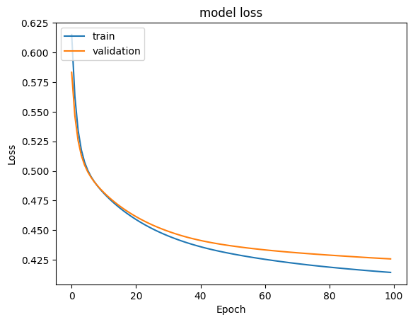

```python
#Plotting Train Loss vs Validation Loss
plt.plot(history_0.history['loss'])
plt.plot(history_0.history['val_loss'])
plt.title('model loss')
plt.ylabel('Loss')
plt.xlabel('Epoch')
plt.legend(['train', 'validation'], loc='upper left')
plt.show()
```

#### Recall Function Plot

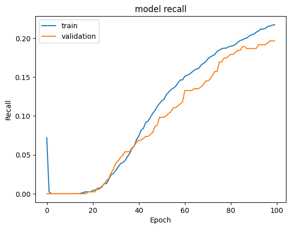

```python
#Plotting Train recall vs Validation recall
plt.plot(history_0.history['recall'])
plt.plot(history_0.history['val_recall'])
plt.title('model recall')
plt.ylabel('Recall')
plt.xlabel('Epoch')
plt.legend(['train', 'validation'], loc='upper left')
plt.show()
```

```python
#Predicting the results using best as a threshold for training data
y_train_pred_0 = model_0.predict(X_train)
y_train_pred_0 = (y_train_pred_0 > 0.5)
y_train_pred_0
```

```
188/188 ━━━━━━━━━━━━━━━━━━━━ 0s 915us/step
```

```
array([[False],
       [False],
       [False],
       ...,
       [False],
       [False],
       [False]])
```

```python
#Predicting the results using 0.5 as the threshold for validation data
y_val_pred_0 = model_0.predict(X_val)
y_val_pred_0 = (y_val_pred_0 > 0.5)
y_val_pred_0
```

```
63/63 ━━━━━━━━━━━━━━━━━━━━ 0s 917us/step
```

```
array([[False],
       [False],
       [False],
       ...,
       [False],
       [False],
       [False]])
```

```python
model_name = "NN with SGD"

train_metric_df.loc[model_name] = recall_score(y_train, y_train_pred_0)
valid_metric_df.loc[model_name] = recall_score(y_val, y_val_pred_0)
```

#### Classification Report

```python
#lassification report for training data
cr=classification_report(y_train, y_train_pred_0)
print(cr)
```

```
              precision    recall  f1-score   support

         0.0       0.83      0.97      0.89      4777
         1.0       0.66      0.22      0.33      1223

    accuracy                           0.82      6000
   macro avg       0.74      0.60      0.61      6000
weighted avg       0.79      0.82      0.78      6000
```

```python
#classification report for validation data
cr=classification_report(y_val, y_val_pred_0)
print(cr)
```

```
              precision    recall  f1-score   support

         0.0       0.83      0.97      0.89      1593
         1.0       0.61      0.20      0.30       407

    accuracy                           0.81      2000
   macro avg       0.72      0.58      0.59      2000
weighted avg       0.78      0.81      0.77      2000
```

#### Confusion Matrix

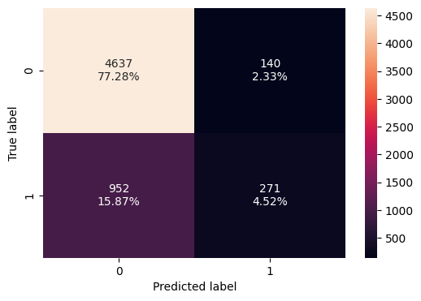

```python
# Confusion matrix for training data
make_confusion_matrix(y_train, y_train_pred_0)
```

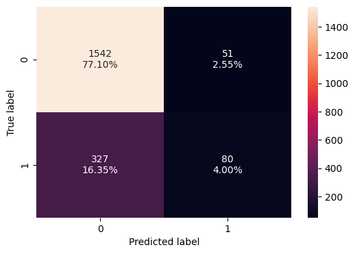

```python
make_confusion_matrix(y_val, y_val_pred_0)
```

## Model Performance Improvement

### Neural Network with Adam Optimizer

```python
#Fixing the seed for random number generators so that we can ensure we receive the same output everytime
np.random.seed(2)
random.seed(2)
tf.random.set_seed(2)
```

```python
#Initializing the neural network
model_1 = Sequential()
#Adding the input layer with 64 neurons and relu as activation function
model_1.add(Dense(64,activation='relu',input_dim = X_train.shape[1]))
# Adding the first hidden layer with 32 neurons with relu as activation functions
model_1.add(Dense(32,activation='relu'))
# Adding the output layer
model_1.add(Dense(1, activation = 'sigmoid'))
#Compiling the ANN with Adam optimizer
optimizer = tf.keras.optimizers.Adam(0.001)
# Complining the model with binary cross entropy as loss function and accuracy as metrics
model_1.compile(loss='binary_crossentropy',optimizer=optimizer,metrics=[keras.metrics.Recall()])
```

```python
model_1.summary()
```

```
Model: "sequential_1"
```

```
┏━━━━━━━━━━━━━━━━━━━━━━━━━━━━━━━━━┳━━━━━━━━━━━━━━━━━━━━━━━━┳━━━━━━━━━━━━━━━┓
┃ Layer (type)                    ┃ Output Shape           ┃       Param # ┃
┡━━━━━━━━━━━━━━━━━━━━━━━━━━━━━━━━━╇━━━━━━━━━━━━━━━━━━━━━━━━╇━━━━━━━━━━━━━━━┩
│ dense_3 (Dense)                 │ (None, 64)             │           768 │
├─────────────────────────────────┼────────────────────────┼───────────────┤
│ dense_4 (Dense)                 │ (None, 32)             │         2,080 │
├─────────────────────────────────┼────────────────────────┼───────────────┤
│ dense_5 (Dense)                 │ (None, 1)              │            33 │
└─────────────────────────────────┴────────────────────────┴───────────────┘
```

```
 Total params: 2,881 (11.25 KB)
```

```
 Trainable params: 2,881 (11.25 KB)
```

```
 Non-trainable params: 0 (0.00 B)
```

```python
#Fitting the ANN with batch_size = 32 and 100 epochs
history_1 = model_1.fit(
    X_train,y_train,
    batch_size=32,
    validation_data=(X_val,y_val),
    epochs=100,
    verbose=1
)
```

```
188/188 ━━━━━━━━━━━━━━━━━━━━ 0s 1ms/step - loss: 0.4930 - recall_1: 0.0480
```

```
188/188 ━━━━━━━━━━━━━━━━━━━━ 2s 3ms/step - loss: 0.4928 - recall_1: 0.0482 - val_loss: 0.4252 - val_recall_1: 0.2088
188/188 ━━━━━━━━━━━━━━━━━━━━ 0s 1ms/step - loss: 0.4017 - recall_1: 0.2285 - val_loss: 0.4140 - val_recall_1: 0.2776
188/188 ━━━━━━━━━━━━━━━━━━━━ 0s 1ms/step - loss: 0.3882 - recall_1: 0.3005 - val_loss: 0.4057 - val_recall_1: 0.3292
188/188 ━━━━━━━━━━━━━━━━━━━━ 0s 1ms/step - loss: 0.3774 - recall_1: 0.3369 - val_loss: 0.3980 - val_recall_1: 0.3489
188/188 ━━━━━━━━━━━━━━━━━━━━ 0s 1ms/step - loss: 0.3673 - recall_1: 0.3601 - val_loss: 0.3914 - val_recall_1: 0.3538
188/188 ━━━━━━━━━━━━━━━━━━━━ 0s 1ms/step - loss: 0.3584 - recall_1: 0.3724 - val_loss: 0.3857 - val_recall_1: 0.3710
188/188 ━━━━━━━━━━━━━━━━━━━━ 0s 2ms/step - loss: 0.3507 - recall_1: 0.3849 - val_loss: 0.3805 - val_recall_1: 0.3857
188/188 ━━━━━━━━━━━━━━━━━━━━ 0s 2ms/step - loss: 0.3436 - recall_1: 0.3984 - val_loss: 0.3752 - val_recall_1: 0.3907
188/188 ━━━━━━━━━━━━━━━━━━━━ 0s 1ms/step - loss: 0.3372 - recall_1: 0.4142 - val_loss: 0.3713 - val_recall_1: 0.3980
188/188 ━━━━━━━━━━━━━━━━━━━━ 0s 1ms/step - loss: 0.3314 - recall_1: 0.4316 - val_loss: 0.3680 - val_recall_1: 0.4005
188/188 ━━━━━━━━━━━━━━━━━━━━ 0s 1ms/step - loss: 0.3261 - recall_1: 0.4423 - val_loss: 0.3650 - val_recall_1: 0.3980
188/188 ━━━━━━━━━━━━━━━━━━━━ 0s 1ms/step - loss: 0.3212 - recall_1: 0.4498 - val_loss: 0.3625 - val_recall_1: 0.4054
188/188 ━━━━━━━━━━━━━━━━━━━━ 0s 1ms/step - loss: 0.3171 - recall_1: 0.4546 - val_loss: 0.3609 - val_recall_1: 0.4103
188/188 ━━━━━━━━━━━━━━━━━━━━ 0s 1ms/step - loss: 0.3135 - recall_1: 0.4670 - val_loss: 0.3595 - val_recall_1: 0.4201
188/188 ━━━━━━━━━━━━━━━━━━━━ 0s 1ms/step - loss: 0.3105 - recall_1: 0.4752 - val_loss: 0.3586 - val_recall_1: 0.4423
188/188 ━━━━━━━━━━━━━━━━━━━━ 0s 1ms/step - loss: 0.3077 - recall_1: 0.4773 - val_loss: 0.3581 - val_recall_1: 0.4398
188/188 ━━━━━━━━━━━━━━━━━━━━ 0s 1ms/step - loss: 0.3051 - recall_1: 0.4908 - val_loss: 0.3581 - val_recall_1: 0.4423
188/188 ━━━━━━━━━━━━━━━━━━━━ 0s 1ms/step - loss: 0.3032 - recall_1: 0.4944 - val_loss: 0.3582 - val_recall_1: 0.4472
188/188 ━━━━━━━━━━━━━━━━━━━━ 0s 1ms/step - loss: 0.3013 - recall_1: 0.5013 - val_loss: 0.3579 - val_recall_1: 0.4545
188/188 ━━━━━━━━━━━━━━━━━━━━ 0s 1ms/step - loss: 0.2998 - recall_1: 0.5079 - val_loss: 0.3584 - val_recall_1: 0.4521
188/188 ━━━━━━━━━━━━━━━━━━━━ 0s 1ms/step - loss: 0.2982 - recall_1: 0.5126 - val_loss: 0.3590 - val_recall_1: 0.4545
188/188 ━━━━━━━━━━━━━━━━━━━━ 0s 1ms/step - loss: 0.2968 - recall_1: 0.5146 - val_loss: 0.3594 - val_recall_1: 0.4570
188/188 ━━━━━━━━━━━━━━━━━━━━ 0s 1ms/step - loss: 0.2956 - recall_1: 0.5233 - val_loss: 0.3596 - val_recall_1: 0.4570
188/188 ━━━━━━━━━━━━━━━━━━━━ 0s 1ms/step - loss: 0.2945 - recall_1: 0.5190 - val_loss: 0.3601 - val_recall_1: 0.4595
188/188 ━━━━━━━━━━━━━━━━━━━━ 0s 1ms/step - loss: 0.2933 - recall_1: 0.5227 - val_loss: 0.3604 - val_recall_1: 0.4644
188/188 ━━━━━━━━━━━━━━━━━━━━ 0s 2ms/step - loss: 0.2925 - recall_1: 0.5237 - val_loss: 0.3610 - val_recall_1: 0.4570
188/188 ━━━━━━━━━━━━━━━━━━━━ 0s 1ms/step - loss: 0.2915 - recall_1: 0.5290 - val_loss: 0.3615 - val_recall_1: 0.4595
188/188 ━━━━━━━━━━━━━━━━━━━━ 0s 1ms/step - loss: 0.2905 - recall_1: 0.5305 - val_loss: 0.3614 - val_recall_1: 0.4619
188/188 ━━━━━━━━━━━━━━━━━━━━ 0s 1ms/step - loss: 0.2896 - recall_1: 0.5292 - val_loss: 0.3621 - val_recall_1: 0.4619
188/188 ━━━━━━━━━━━━━━━━━━━━ 0s 1ms/step - loss: 0.2888 - recall_1: 0.5302 - val_loss: 0.3623 - val_recall_1: 0.4717
188/188 ━━━━━━━━━━━━━━━━━━━━ 0s 1ms/step - loss: 0.2879 - recall_1: 0.5310 - val_loss: 0.3632 - val_recall_1: 0.4693
188/188 ━━━━━━━━━━━━━━━━━━━━ 0s 1ms/step - loss: 0.2871 - recall_1: 0.5349 - val_loss: 0.3635 - val_recall_1: 0.4693
188/188 ━━━━━━━━━━━━━━━━━━━━ 0s 2ms/step - loss: 0.2863 - recall_1: 0.5340 - val_loss: 0.3638 - val_recall_1: 0.4693
188/188 ━━━━━━━━━━━━━━━━━━━━ 0s 1ms/step - loss: 0.2854 - recall_1: 0.5337 - val_loss: 0.3646 - val_recall_1: 0.4644
188/188 ━━━━━━━━━━━━━━━━━━━━ 0s 1ms/step - loss: 0.2846 - recall_1: 0.5348 - val_loss: 0.3652 - val_recall_1: 0.4693
188/188 ━━━━━━━━━━━━━━━━━━━━ 0s 1ms/step - loss: 0.2839 - recall_1: 0.5395 - val_loss: 0.3658 - val_recall_1: 0.4717
188/188 ━━━━━━━━━━━━━━━━━━━━ 0s 1ms/step - loss: 0.2832 - recall_1: 0.5455 - val_loss: 0.3662 - val_recall_1: 0.4717
188/188 ━━━━━━━━━━━━━━━━━━━━ 0s 1ms/step - loss: 0.2826 - recall_1: 0.5464 - val_loss: 0.3672 - val_recall_1: 0.4693
188/188 ━━━━━━━━━━━━━━━━━━━━ 0s 1ms/step - loss: 0.2818 - recall_1: 0.5459 - val_loss: 0.3674 - val_recall_1: 0.4742
188/188 ━━━━━━━━━━━━━━━━━━━━ 0s 2ms/step - loss: 0.2813 - recall_1: 0.5481 - val_loss: 0.3682 - val_recall_1: 0.4742
```

[output cut: 45 more lines]

```
188/188 ━━━━━━━━━━━━━━━━━━━━ 0s 1ms/step - loss: 0.2474 - recall_1: 0.6117 - val_loss: 0.3982 - val_recall_1: 0.4447
188/188 ━━━━━━━━━━━━━━━━━━━━ 0s 1ms/step - loss: 0.2468 - recall_1: 0.6147 - val_loss: 0.3991 - val_recall_1: 0.4423
188/188 ━━━━━━━━━━━━━━━━━━━━ 0s 1ms/step - loss: 0.2461 - recall_1: 0.6166 - val_loss: 0.3998 - val_recall_1: 0.4496
188/188 ━━━━━━━━━━━━━━━━━━━━ 0s 1ms/step - loss: 0.2457 - recall_1: 0.6229 - val_loss: 0.4010 - val_recall_1: 0.4398
188/188 ━━━━━━━━━━━━━━━━━━━━ 0s 1ms/step - loss: 0.2450 - recall_1: 0.6208 - val_loss: 0.4016 - val_recall_1: 0.4496
188/188 ━━━━━━━━━━━━━━━━━━━━ 0s 1ms/step - loss: 0.2446 - recall_1: 0.6217 - val_loss: 0.4025 - val_recall_1: 0.4423
188/188 ━━━━━━━━━━━━━━━━━━━━ 0s 1ms/step - loss: 0.2437 - recall_1: 0.6249 - val_loss: 0.4032 - val_recall_1: 0.4472
188/188 ━━━━━━━━━━━━━━━━━━━━ 0s 1ms/step - loss: 0.2431 - recall_1: 0.6238 - val_loss: 0.4041 - val_recall_1: 0.4447
188/188 ━━━━━━━━━━━━━━━━━━━━ 0s 1ms/step - loss: 0.2427 - recall_1: 0.6267 - val_loss: 0.4047 - val_recall_1: 0.4521
188/188 ━━━━━━━━━━━━━━━━━━━━ 0s 1ms/step - loss: 0.2419 - recall_1: 0.6271 - val_loss: 0.4059 - val_recall_1: 0.4423
188/188 ━━━━━━━━━━━━━━━━━━━━ 0s 1ms/step - loss: 0.2414 - recall_1: 0.6381 - val_loss: 0.4070 - val_recall_1: 0.4398
188/188 ━━━━━━━━━━━━━━━━━━━━ 0s 1ms/step - loss: 0.2406 - recall_1: 0.6386 - val_loss: 0.4081 - val_recall_1: 0.4373
188/188 ━━━━━━━━━━━━━━━━━━━━ 0s 1ms/step - loss: 0.2402 - recall_1: 0.6330 - val_loss: 0.4080 - val_recall_1: 0.4398
188/188 ━━━━━━━━━━━━━━━━━━━━ 0s 1ms/step - loss: 0.2394 - recall_1: 0.6331 - val_loss: 0.4092 - val_recall_1: 0.4423
188/188 ━━━━━━━━━━━━━━━━━━━━ 0s 1ms/step - loss: 0.2389 - recall_1: 0.6378 - val_loss: 0.4102 - val_recall_1: 0.4472
```

###### Loss Function Plot

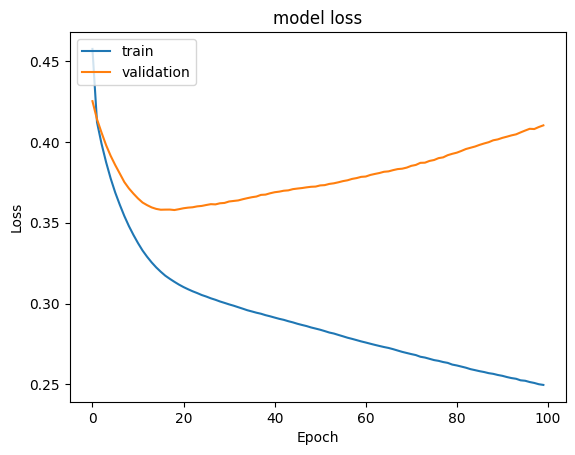

```python
#Plotting Train Loss vs Validation Loss
plt.plot(history_1.history['loss'])
plt.plot(history_1.history['val_loss'])
plt.title('model loss')
plt.ylabel('Loss')
plt.xlabel('Epoch')
plt.legend(['train', 'validation'], loc='upper left')
plt.show()
```

#### Recall Function Plot

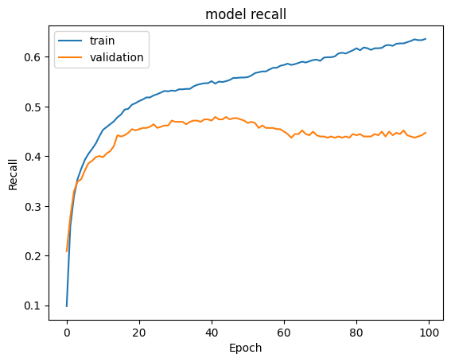

```python
#Plotting Train recall vs Validation recall
plt.plot(history_1.history['recall_1'])
plt.plot(history_1.history['val_recall_1'])
plt.title('model recall')
plt.ylabel('Recall')
plt.xlabel('Epoch')
plt.legend(['train', 'validation'], loc='upper left')
plt.show()
```

```python
#Predicting the results using 0.5 as the threshold for training data
y_train_pred_1=model_1.predict(X_train)
y_train_pred_1 = (y_train_pred_1 > 0.5)
y_train_pred_1
```

```
188/188 ━━━━━━━━━━━━━━━━━━━━ 0s 903us/step
```

```
array([[False],
       [False],
       [ True],
       ...,
       [ True],
       [False],
       [ True]])
```

```python
#Predicting the results using 0.5 as the threshold
y_val_pred_1=model_1.predict(X_val)
y_val_pred_1 = (y_val_pred_1 > 0.5)
y_val_pred_1
```

```
63/63 ━━━━━━━━━━━━━━━━━━━━ 0s 1ms/step
```

```
array([[False],
       [False],
       [ True],
       ...,
       [False],
       [False],
       [False]])
```

```python
model_name = "NN with Adam"

train_metric_df.loc[model_name] = recall_score(y_train,y_train_pred_1)
valid_metric_df.loc[model_name] = recall_score(y_val,y_val_pred_1)
```

##### Classification Report

```python
#classification report Training data
cr = classification_report(y_train,y_train_pred_1)
print(cr)
```

```
              precision    recall  f1-score   support

         0.0       0.91      0.97      0.94      4777
         1.0       0.86      0.62      0.72      1223

    accuracy                           0.90      6000
   macro avg       0.89      0.80      0.83      6000
weighted avg       0.90      0.90      0.90      6000
```

```python
#classification report Validation data
cr = classification_report(y_val,y_val_pred_1)
print(cr)
```

```
              precision    recall  f1-score   support

         0.0       0.87      0.94      0.90      1593
         1.0       0.65      0.45      0.53       407

    accuracy                           0.84      2000
   macro avg       0.76      0.69      0.72      2000
weighted avg       0.83      0.84      0.83      2000
```

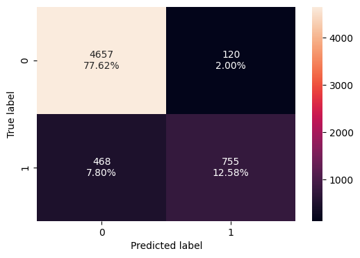

```python
#Calculating the confusion matrix
make_confusion_matrix(y_train, y_train_pred_1)
```

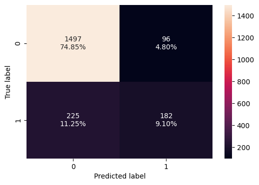

```python
#Calculating the confusion matrix
make_confusion_matrix(y_val,y_val_pred_1)
```

### Neural Network with Adam Optimizer and Dropout

```python
backend.clear_session()
#Fixing the seed for random number generators so that we can ensure we receive the same output everytime
np.random.seed(2)
random.seed(2)
tf.random.set_seed(2)
```

```python
#Initializing the neural network
model_2 = Sequential()
#Adding the input layer with 32 neurons and relu as activation function
model_2.add(Dense(32,activation='relu',input_dim = X_train.shape[1]))
# Adding dropout with ratio of 0.2
model_2.add(Dropout(0.2))
# Adding the first hidden layer with 16 neurons with relu as activation functions
model_2.add(Dense(32,activation='relu'))
model_2.add(Dense(16,activation='relu'))
model_2.add(Dropout(0.1))
# Adding the second hidden layer with 8 neurons with relu as activation functions
model_2.add(Dense(8,activation='relu'))
# Adding the output layer
model_2.add(Dense(1, activation = 'sigmoid'))
```

```python
# Summary of the model
model_2.summary()
```

```
Model: "sequential"
```

```
┏━━━━━━━━━━━━━━━━━━━━━━━━━━━━━━━━━┳━━━━━━━━━━━━━━━━━━━━━━━━┳━━━━━━━━━━━━━━━┓
┃ Layer (type)                    ┃ Output Shape           ┃       Param # ┃
┡━━━━━━━━━━━━━━━━━━━━━━━━━━━━━━━━━╇━━━━━━━━━━━━━━━━━━━━━━━━╇━━━━━━━━━━━━━━━┩
│ dense (Dense)                   │ (None, 32)             │           384 │
├─────────────────────────────────┼────────────────────────┼───────────────┤
│ dropout (Dropout)               │ (None, 32)             │             0 │
├─────────────────────────────────┼────────────────────────┼───────────────┤
│ dense_1 (Dense)                 │ (None, 32)             │         1,056 │
├─────────────────────────────────┼────────────────────────┼───────────────┤
│ dense_2 (Dense)                 │ (None, 16)             │           528 │
├─────────────────────────────────┼────────────────────────┼───────────────┤
│ dropout_1 (Dropout)             │ (None, 16)             │             0 │
├─────────────────────────────────┼────────────────────────┼───────────────┤
│ dense_3 (Dense)                 │ (None, 8)              │           136 │
├─────────────────────────────────┼────────────────────────┼───────────────┤
│ dense_4 (Dense)                 │ (None, 1)              │             9 │
└─────────────────────────────────┴────────────────────────┴───────────────┘
```

```
 Total params: 2,113 (8.25 KB)
```

```
 Trainable params: 2,113 (8.25 KB)
```

```
 Non-trainable params: 0 (0.00 B)
```

```python
#Compiling the ANN with Adam optimizer
optimizer = tf.keras.optimizers.Adam(0.001)
# Compiling the model with binary cross entropy as loss function and accuracy as metrics

model_2.compile(loss='binary_crossentropy',optimizer=optimizer,metrics=[keras.metrics.Recall()])
```

```python
#Fitting the ANN with batch_size = 32 and 100 epochs
history_2 = model_2.fit(X_train,y_train,batch_size=32,epochs=100,verbose=1,validation_data=(X_val,y_val))
```

```
188/188 ━━━━━━━━━━━━━━━━━━━━ 2s 3ms/step - loss: 0.5460 - recall: 0.0856 - val_loss: 0.4432 - val_recall: 0.0025
188/188 ━━━━━━━━━━━━━━━━━━━━ 0s 1ms/step - loss: 0.4359 - recall: 0.0395 - val_loss: 0.4337 - val_recall: 0.1351
188/188 ━━━━━━━━━━━━━━━━━━━━ 0s 2ms/step - loss: 0.4309 - recall: 0.1005 - val_loss: 0.4305 - val_recall: 0.1499
188/188 ━━━━━━━━━━━━━━━━━━━━ 0s 1ms/step - loss: 0.4203 - recall: 0.1550 - val_loss: 0.4260 - val_recall: 0.1794
188/188 ━━━━━━━━━━━━━━━━━━━━ 0s 1ms/step - loss: 0.4163 - recall: 0.1608 - val_loss: 0.4204 - val_recall: 0.2383
188/188 ━━━━━━━━━━━━━━━━━━━━ 0s 2ms/step - loss: 0.4102 - recall: 0.2202 - val_loss: 0.4134 - val_recall: 0.2899
188/188 ━━━━━━━━━━━━━━━━━━━━ 0s 1ms/step - loss: 0.4076 - recall: 0.2291 - val_loss: 0.4094 - val_recall: 0.3120
188/188 ━━━━━━━━━━━━━━━━━━━━ 0s 1ms/step - loss: 0.3964 - recall: 0.2659 - val_loss: 0.4070 - val_recall: 0.3047
188/188 ━━━━━━━━━━━━━━━━━━━━ 0s 2ms/step - loss: 0.3948 - recall: 0.2903 - val_loss: 0.4036 - val_recall: 0.3047
188/188 ━━━━━━━━━━━━━━━━━━━━ 0s 1ms/step - loss: 0.3943 - recall: 0.2757 - val_loss: 0.4015 - val_recall: 0.3120
188/188 ━━━━━━━━━━━━━━━━━━━━ 0s 1ms/step - loss: 0.3847 - recall: 0.3059 - val_loss: 0.4000 - val_recall: 0.3120
188/188 ━━━━━━━━━━━━━━━━━━━━ 0s 1ms/step - loss: 0.3882 - recall: 0.2985 - val_loss: 0.3992 - val_recall: 0.3440
188/188 ━━━━━━━━━━━━━━━━━━━━ 0s 1ms/step - loss: 0.3875 - recall: 0.3066 - val_loss: 0.3973 - val_recall: 0.3391
188/188 ━━━━━━━━━━━━━━━━━━━━ 0s 1ms/step - loss: 0.3865 - recall: 0.3163 - val_loss: 0.3929 - val_recall: 0.3464
188/188 ━━━━━━━━━━━━━━━━━━━━ 0s 1ms/step - loss: 0.3761 - recall: 0.3435 - val_loss: 0.3888 - val_recall: 0.3686
188/188 ━━━━━━━━━━━━━━━━━━━━ 0s 1ms/step - loss: 0.3727 - recall: 0.3389 - val_loss: 0.3854 - val_recall: 0.3563
188/188 ━━━━━━━━━━━━━━━━━━━━ 0s 1ms/step - loss: 0.3735 - recall: 0.3616 - val_loss: 0.3801 - val_recall: 0.3931
188/188 ━━━━━━━━━━━━━━━━━━━━ 0s 1ms/step - loss: 0.3696 - recall: 0.3730 - val_loss: 0.3778 - val_recall: 0.3735
188/188 ━━━━━━━━━━━━━━━━━━━━ 0s 1ms/step - loss: 0.3640 - recall: 0.3777 - val_loss: 0.3732 - val_recall: 0.4005
188/188 ━━━━━━━━━━━━━━━━━━━━ 0s 1ms/step - loss: 0.3613 - recall: 0.3969 - val_loss: 0.3711 - val_recall: 0.4029
188/188 ━━━━━━━━━━━━━━━━━━━━ 0s 1ms/step - loss: 0.3549 - recall: 0.3957 - val_loss: 0.3661 - val_recall: 0.4103
188/188 ━━━━━━━━━━━━━━━━━━━━ 0s 1ms/step - loss: 0.3505 - recall: 0.4039 - val_loss: 0.3642 - val_recall: 0.4300
188/188 ━━━━━━━━━━━━━━━━━━━━ 0s 1ms/step - loss: 0.3463 - recall: 0.4312 - val_loss: 0.3636 - val_recall: 0.4349
188/188 ━━━━━━━━━━━━━━━━━━━━ 0s 1ms/step - loss: 0.3470 - recall: 0.4404 - val_loss: 0.3596 - val_recall: 0.3956
188/188 ━━━━━━━━━━━━━━━━━━━━ 0s 1ms/step - loss: 0.3407 - recall: 0.4140 - val_loss: 0.3560 - val_recall: 0.4668
188/188 ━━━━━━━━━━━━━━━━━━━━ 0s 1ms/step - loss: 0.3416 - recall: 0.4574 - val_loss: 0.3555 - val_recall: 0.4201
188/188 ━━━━━━━━━━━━━━━━━━━━ 0s 1ms/step - loss: 0.3386 - recall: 0.4254 - val_loss: 0.3541 - val_recall: 0.4373
188/188 ━━━━━━━━━━━━━━━━━━━━ 0s 1ms/step - loss: 0.3391 - recall: 0.4244 - val_loss: 0.3530 - val_recall: 0.4472
188/188 ━━━━━━━━━━━━━━━━━━━━ 0s 1ms/step - loss: 0.3305 - recall: 0.4544 - val_loss: 0.3506 - val_recall: 0.4717
188/188 ━━━━━━━━━━━━━━━━━━━━ 0s 2ms/step - loss: 0.3355 - recall: 0.4420 - val_loss: 0.3524 - val_recall: 0.4570
188/188 ━━━━━━━━━━━━━━━━━━━━ 0s 1ms/step - loss: 0.3338 - recall: 0.4344 - val_loss: 0.3502 - val_recall: 0.4595
188/188 ━━━━━━━━━━━━━━━━━━━━ 0s 1ms/step - loss: 0.3350 - recall: 0.4380 - val_loss: 0.3483 - val_recall: 0.4644
188/188 ━━━━━━━━━━━━━━━━━━━━ 0s 1ms/step - loss: 0.3305 - recall: 0.4414 - val_loss: 0.3476 - val_recall: 0.4644
188/188 ━━━━━━━━━━━━━━━━━━━━ 0s 1ms/step - loss: 0.3326 - recall: 0.4631 - val_loss: 0.3470 - val_recall: 0.4644
188/188 ━━━━━━━━━━━━━━━━━━━━ 0s 1ms/step - loss: 0.3273 - recall: 0.4496 - val_loss: 0.3486 - val_recall: 0.4496
188/188 ━━━━━━━━━━━━━━━━━━━━ 0s 1ms/step - loss: 0.3232 - recall: 0.4517 - val_loss: 0.3502 - val_recall: 0.4275
188/188 ━━━━━━━━━━━━━━━━━━━━ 0s 1ms/step - loss: 0.3296 - recall: 0.4180 - val_loss: 0.3541 - val_recall: 0.4742
188/188 ━━━━━━━━━━━━━━━━━━━━ 0s 1ms/step - loss: 0.3218 - recall: 0.4698 - val_loss: 0.3487 - val_recall: 0.4644
188/188 ━━━━━━━━━━━━━━━━━━━━ 0s 1ms/step - loss: 0.3239 - recall: 0.4590 - val_loss: 0.3494 - val_recall: 0.4595
188/188 ━━━━━━━━━━━━━━━━━━━━ 0s 2ms/step - loss: 0.3257 - recall: 0.4676 - val_loss: 0.3493 - val_recall: 0.4521
```

[output cut: 45 more lines]

```
188/188 ━━━━━━━━━━━━━━━━━━━━ 0s 1ms/step - loss: 0.3100 - recall: 0.4790 - val_loss: 0.3577 - val_recall: 0.4570
188/188 ━━━━━━━━━━━━━━━━━━━━ 0s 2ms/step - loss: 0.3095 - recall: 0.4672 - val_loss: 0.3590 - val_recall: 0.4668
188/188 ━━━━━━━━━━━━━━━━━━━━ 0s 1ms/step - loss: 0.3060 - recall: 0.4843 - val_loss: 0.3594 - val_recall: 0.4619
188/188 ━━━━━━━━━━━━━━━━━━━━ 0s 2ms/step - loss: 0.3106 - recall: 0.4853 - val_loss: 0.3622 - val_recall: 0.4742
188/188 ━━━━━━━━━━━━━━━━━━━━ 0s 2ms/step - loss: 0.3097 - recall: 0.4866 - val_loss: 0.3564 - val_recall: 0.4570
188/188 ━━━━━━━━━━━━━━━━━━━━ 0s 1ms/step - loss: 0.3093 - recall: 0.4831 - val_loss: 0.3614 - val_recall: 0.4816
188/188 ━━━━━━━━━━━━━━━━━━━━ 0s 2ms/step - loss: 0.3072 - recall: 0.4880 - val_loss: 0.3591 - val_recall: 0.4570
188/188 ━━━━━━━━━━━━━━━━━━━━ 0s 2ms/step - loss: 0.3095 - recall: 0.4797 - val_loss: 0.3656 - val_recall: 0.4865
188/188 ━━━━━━━━━━━━━━━━━━━━ 0s 1ms/step - loss: 0.3067 - recall: 0.4862 - val_loss: 0.3616 - val_recall: 0.4619
188/188 ━━━━━━━━━━━━━━━━━━━━ 0s 2ms/step - loss: 0.3095 - recall: 0.4751 - val_loss: 0.3588 - val_recall: 0.4767
188/188 ━━━━━━━━━━━━━━━━━━━━ 0s 1ms/step - loss: 0.3051 - recall: 0.4839 - val_loss: 0.3603 - val_recall: 0.4619
188/188 ━━━━━━━━━━━━━━━━━━━━ 0s 1ms/step - loss: 0.3083 - recall: 0.4762 - val_loss: 0.3620 - val_recall: 0.4791
188/188 ━━━━━━━━━━━━━━━━━━━━ 0s 2ms/step - loss: 0.3045 - recall: 0.4979 - val_loss: 0.3591 - val_recall: 0.4472
188/188 ━━━━━━━━━━━━━━━━━━━━ 0s 2ms/step - loss: 0.3042 - recall: 0.4764 - val_loss: 0.3604 - val_recall: 0.4668
188/188 ━━━━━━━━━━━━━━━━━━━━ 0s 2ms/step - loss: 0.3024 - recall: 0.5000 - val_loss: 0.3583 - val_recall: 0.4521
```